# 条件分岐と繰り返し処理1

### 複素数の場合

さて、複素数まで考えれば$x^3 -1 = 0$の解は三つ存在し、それぞれ$x=1, -1/2 \pm \sqrt{3}/2 i$である。複素数の場合にもニュートン法が機能することを確認しよう。先程の関数に、そのまま複素数を入れて実行してみよ。まずは実軸にある点を入力してみる。

```python
newton(2+0j)
```

```bash
(1.4166666666666665+0j)
(1.1105344098423682+0j)
(1.0106367684045563+0j)
(1.0001115573039492+0j)
(1.0000000124431812+0j)
(1.0000000000000002+0j)
(1+0j)
(1+0j)
(1+0j)
(1+0j)
(1+0j)
```

次は`-1 + 1j`を入力してみよう。

```python
newton(-1+1j)
```

```bash
(-0.6666666666666667+0.8333333333333334j)
(-0.5086919161874546+0.8410998744133783j)
(-0.49932999564375125+0.8662691717880057j)
(-0.4999999113699129+0.8660249031568892j)
(-0.4999999999999555+0.8660254037846933j)
(-0.5+0.8660254037844386j)
(-0.5+0.8660254037844387j)
(-0.5+0.8660254037844386j)
(-0.5+0.8660254037844387j)
(-0.5+0.8660254037844386j)
(-0.5+0.8660254037844386j)
```

$x=-1/2 + \sqrt{3}/2 i$に収束した。同様に初期値として`-1-1j`を入力してみる。

```python
newton(-1-1j)
```

```bash
(-0.6666666666666667-0.8333333333333334j)
(-0.5086919161874546-0.8410998744133783j)
(-0.49932999564375125-0.8662691717880057j)
(-0.4999999113699129-0.8660249031568892j)
(-0.4999999999999555-0.8660254037846933j)
(-0.5-0.8660254037844386j)
(-0.5-0.8660254037844387j)
(-0.5-0.8660254037844386j)
(-0.5-0.8660254037844387j)
(-0.5-0.8660254037844386j)
(-0.5-0.8660254037844386j)
```

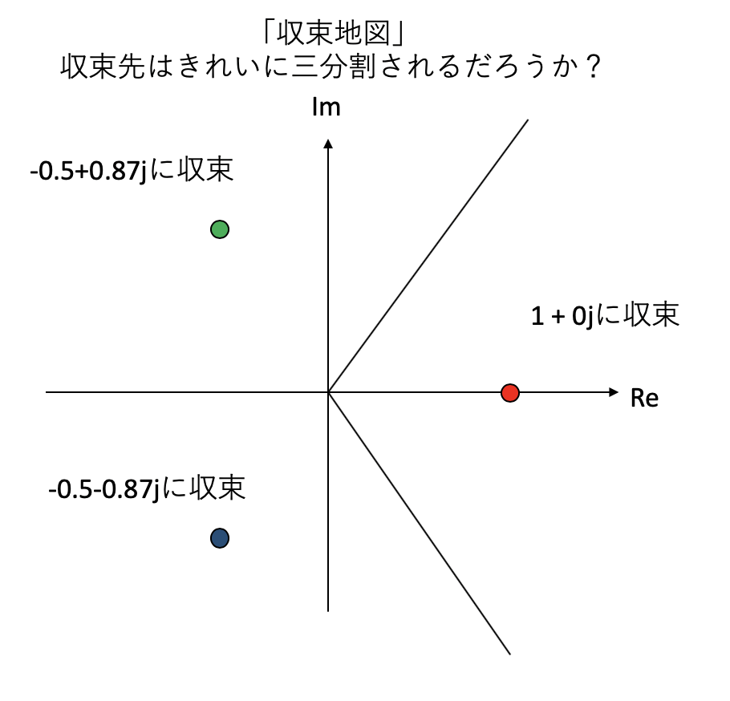

map.png

複素平面の様々な場所を初期として、

### 課題1

新しいノートブックを開き、以下のプログラムを4つのセルに分けて入力せよ。

1つ目のセル。

```python
from PIL import Image, ImageDraw
import IPython
```

2つ目のセル。

```python
def newton(x):
  for _ in range(10):
    x = x - (x**3-1)/(3*x**2)
  return x
```

`return x`のインデントに注意。`x = x - (x**3-1)/(3*x**2)`ではなく、`for`と同じ高さにしなければならない。

3つ目のセル。

```python
def plot(draw, s):
    hs = s/2
    red = (255, 0, 0)
    green = (0, 255, 0)
    blue = (0, 0, 255)
    for x in range(s):
        for y in range(s):
            z = complex(x-hs, y-hs)/s*4 + 0.01
            z = newton(z)
            # ここを埋めよ
            draw.rectangle([x, y, x+1, y+1], fill=c)
```

上記の「ここを埋めよ」の箇所に

- `z`の実部が正なら`c = red`
- `z`の実部が負かつ虚部が正なら`c = green`
- `z`の実部が負かつ虚部も負なら`c = blue`

を実行するようにプログラムを書くこと。

4つ目のセル。

```python
size = 512
im = Image.new("RGB", (size, size))
draw = ImageDraw.Draw(im)
plot(draw, size)
im.save("test.png")
IPython.display.Image("test.png")
```

正しく入力できていれば、「収束地図」が描けたはずだ。どのような地図になっただろうか？

### 課題2

先程は$x^3 - 1 = 0$の解を考えた。次は$x^4 - 1 = 0$の解を考えてみよう。この方程式には$x = \pm 1$、$x \pm i$の4つの解が存在する。この解をニュートン法で探し、「収束地図」を描こう。

まず、先程の課題で作成したプログラムに名前をつけて保存し、複製して、そちらを修正することにしよう。ファイルメニューから「名前を変更」をクリック、もしくは上の「Untitled.ipynb」をクリックし、「newton.ipynb」と名前を変えよう。その後、「ファイル」メニューの「保存」を選ぶと保存される。

この状態で「ファイル」メニューから「ドライブで探す」をクリックせよ。「マイドライブ」の「Colab Notebooks」に「newton.ipynb」があるはずである。それを右クリックし「コピーを作成」を選ぶと「newton.ipynbのコピー」というファイルが作成されるので、それを右クリックして「名前を変更」を選び、「newton2.ipynb」という名前にしよう。「newton2.ipynb」が作成されたら、右クリック→「アプリで開く」→「Colaboratory」を選ぶことで開くことができる。

「newton2.ipynb」が開かれたら、まず2つ目のセルにある関数`newton`を次のように修正しよう。

```python
def newton(x):
  for _ in range(10):
    x = x - (x**4-1)/(4*x**3)
  return x
```

$f(x) = x^4 -1$とし、$f(x)$と$f'(x)$を公式に代入しただけである。

次に、3つ目のセルにある関数`plot`を次のように修正しよう。

```python
def plot(draw, s):
    hs = s/2
    red = (255, 0, 0)
    green = (0, 255, 0)
    blue = (0, 0, 255)
    purple = (255, 0 ,255)  # ここを追加
    for x in range(s):
        for y in range(s):
            z = complex(x-hs, y-hs)/s*4 + 0.01
            z = newton(z)
            # ここを埋めよ
            draw.rectangle([x, y, x+1, y+1], fill=c)
```

解がそれぞれ1, -1, j, -jなので、

- `z`の実部が正かつ虚部が正なら`c = red`
- `z`の実部が正かつ虚部が負なら`c = green`
- `z`の実部が負かつ虚部が正なら`c = blue`
- `z`の実部が負かつ虚部も負なら`c = purple`

となるように「# ここを埋めよ」の部分を書け。

4つ目のセルはそのままで良い。すべてのセルを上から順番に実行、もしくは「ランタイム」メニューから「すべてのセルを実行」を実行せよ。もしおかしなことになったら、「ランタイム」から「再起動してすべてのセルを実行」せよ。

ニュートン法の繰り返し数が10だと原点付近の収束が甘い。20くらいにして再実行してみよ。逆に5に減らすとどうなるだろうか？

### 任意課題

TODO: 収束の回数に応じたグラデーション

## 余談：バグについて

プログラムが何か意図しない動作をする場合、その原因となる箇所を「バグ」と呼ぶ。バグの語源については諸説あるようだが、詳しいことはわからない。 「i」と「l」と「1」など、似ている文字を誤入力してしまったり、考慮すべきケースを忘れていたり、バグの原因は様々である。 単純なバグについては、コンパイラや検査ツールの充実、テスト手法の向上などにより事前に検出できるようになってきた。 そんななか、未だによく見かけるバグに「オーバーフロー/アンダーフローバグ」がある。コンピュータが扱える数字には上限がある。 たとえば整数は32ビットで表現されることが多い。符号無し整数の場合、表現できる最大の数は4294967295、つまり43億ちょっとである。 符号付きの場合は、符号に1ビット使うので最大の数はその半分になる。 この数字を超える、すなわち最大値を取っている変数に1を足すと、またゼロに戻ってしまう。オーバーフローバグは、よくタイマー周りに潜む。 最近だと、ボーイング787という飛行機の電源制御システムが、連続して248日動作させると不具合を起こすことが報告された。 慣れたプログラマなら、「248日」と聞いた瞬間に「あ、オーバーフローやったな」と気がつく。 248日とは21427200秒である。31ビットで表現できる最大の数は2147483647であるから10ミリ秒を単位に動作する31ビットのクロックが、 248日でオーバーフローしたと考えられる。同根のバグに「497日問題」とか「49.7日問題」があるので、興味があれば調べられたい。

オーバーフローとは逆に、値が0になってるのに引き算をして、値が逆に大きくなるバグもあり、アンダーフローバグと呼ばれている。 アンダーフローバグで有名なのは「突然キレるガンジー」であろう。 Cibilizationという、文明を発展させるゲームがある。歴史上の有名人をプレイヤーとして選び、 世界制覇などを目指すゲームである。この中のプレイヤーにガンジーがいた。 ガンジーは「非暴力、不服従」の提唱者であり、平和主義者なのであるが、文明がある程度発展すると 突如として核攻撃をしかけてくるようになる。これはアンダーフローバグであった。 Cibilizationでは各プレイヤーには攻撃性が設定されており、 文明が民主主義を採用すると攻撃性が2下がる、という仕組みがあった。 さて、ガンジーの攻撃性は1なのだが、インド文明が民主主義を採用し2を引くと-1になる。 しかし、攻撃性は「符号なし8ビット整数」で表現されていたため、1から2を引くと攻撃性最大の255になってしまった。 こうして「突然キレるガンジー」が誕生したのである。

整数の表現できる数値に最大値があることに起因するバグは根深く、発見が難しい。 かくいう私も、4294967295回に一度意図しない動作をするというエグいバグを入れたことがある。 43億回に一度発生するため、研究室のPCでは再現せず、スパコンを使ったときにたまに発生する、という感じだったので 原因究明に時間がかかった。バグという概念が生まれてかなりの時間がたったが、まだ人類はバグを根絶できていない。 それなら僕がバグを入れるのもやむを得まい(言い訳である)。

参考：[オーバーフローが引き起こした面白いバグの話](https://note.mu/ruiu/n/n89d18450b1bb)